R E V I E W

Withania somnifera (Indian ginseng) in diabetes mellitus:

A systematic review and meta-analysis of scientific evidence

from experimental research to clinical application

Sharanbasappa Durg<sup>1</sup>

|

Sachin Bavage<sup>1</sup>

|

Shivakumar B. Shivaram<sup>2</sup>

1Independent Researcher, Bidar, Karnataka,

India

2Independent Researcher, Bengaluru,

Karnataka, India

Correspondence

Sharanbasappa Durg, H.No. 19-5-244/15,

Ganachari Layout, Near Lumbini Nagar,

Naubad, Bidar 585402, Karnataka, India.

Email: sharanabasappadurg@yahoo.com;

Withania somnifera Dunal, also known as Indian ginseng, has been in use since

ancient times in the management of diabetes mellitus (DM). This systematic review

and meta-analysis evaluated the efficacy/effectiveness, safety and tolerability of

W. somnifera in managing DM. Literature search (published/unpublished) was per-

formed from inception to April 2019 in guidelines recommended databases. A total

of 6 in-vitro, 13 pre-clinical and 5 clinical studies were included for systematic evalu-

ation. W. somnifera treatment in DM significantly restored the altered levels of blood

glucose (experimental data; mean difference, −196.27; 95% confidence interval

[−220.96, −171.58]; p < .00001) glycosylated haemoglobin (HbA1c), insulin, lipid

profile, serum and oxidative stress markers with no safety concerns. The results sug-

gest the potential role of W. somnifera in managing DM. However, the available clini-

cal data are not considerably enough to provide novel and sufficiently robust

evidence for the use of W. somnifera in managing DM. To further strength the anti-

diabetic profile of W. somnifera, well-designed randomized-controlled trial(s) with a

larger sample size and longer duration is warranted with evaluation of its effect pri-

marily on blood glucose, HbA1c and insulin. Future research also needs to elucidate

the molecular mechanism(s) of W. somnifera including its active principles in DM.

K E Y W O R D S

diabetes mellitus, Indian ginseng, meta-analysis, oxidative stress, systematic review

1

|

INTRODUCTION

Diabetes mellitus (DM), a chronic and progressive heterogeneous

metabolic disorder, is characterized by elevated levels of blood

glucose—a common effect if uncontrolled, may gradually lead to

serious damage to the heart, blood vessels, eyes, kidneys and nerves

(Guariguata et al., 2014; World Health Organization, 2016). Due to

diabetes, in 2012, there were 1.5 million deaths, and elevated blood

glucose additionally led to 2.2 million deaths due to increased risks

of

cardiovascular

(CV)

and

other

diseases

(World

Health

Organization, 2016). The latest WHO report states that the global

estimates of diabetes prevalence, in adult population, had nearly

doubled from 1980 to 2014, rising from 4.7% (108 million) to 8.5%

(422 million; World Health Organization, 2016). Further, as per

2013 estimate (in millions), China (98.4) had the highest number of

adult population with diabetes, followed by India (65.1) and the

United States (24.4): the projections for 2035 also showed continu-

ing increase in patients with diabetes in these three countries

(in millions); 142.7, 109.0 and 29.7, respectively (Guariguata et al.,

2014). With the increasing burden of diabetes, effective preventive

measures and management are required to reduce an individual's

risk of developing diabetes and its complications. Scientific evidence

shows that lifestyle interventions such as healthy diet and physical

Dedication: The authors dedicate this work to his holiness Dr Sri Shivakumar Swamiji who is

an inspiration to millions of lives to serve the humanity.

Received: 2 September 2019

Revised: 17 November 2019

Accepted: 26 November 2019

DOI: 10.1002/ptr.6589

Phytotherapy Research. 2020;34:1041–1059.

wileyonlinelibrary.com/journal/ptr

© 2020 John Wiley & Sons, Ltd.

1041

activity

are

more

effective

than

medication

in

delaying

or

preventing diabetes, especially in whose who are overweight or

with impaired glucose tolerance (Diabetes Prevention Program

Research Group, 2009, 2015; Knowler et al., 2002; Lim et al., 2011;

Tuomilehto et al., 2001). The concept of ancient Indian System of

Medicine (ISM; Ayurveda) also emphasizes healthy eating with regu-

lar physical and psychological exercises for preventing and manag-

ing diabetes (Sharma & Chandola, 2011).

Withania somnifera Dunal (in Sanskrit, Hayagandh�a/V�ajigandh�a;

Family, Solanaceae), commonly known as Indian ginseng, winter

cherry and ajagandha, is a dietary supplement with various nutrients

and phytochemicals in its composition (Department of AYUSH, 1989;

Facciola, 1998; Udayakumar et al., 2010). The ISM describes

W. somnifera as Rasayanas (rejuvenating tonic), which promote health

and longevity, and create a sense of mental well-being (Dar, Hamid, &

Ahmad, 2015; Durg, Dhadde, Vandal, Shivakumar, & Charan, 2015;

Durg, Shivaram, & Bavage, 2018; Kuppurajan et al., 1980; D. B.

A. Narayana, Durg, Manohar, Mahapatra, & Aramya, 2017; Weiner &

Weiner, 1994). The European Commission recognizes W. somnifera

as a food or food ingredient, and its access to the market is not sub-

ject to the Novel Food Regulation (EC) No. 258/97 (http://ec.

europa.eu/food/safety/novel_food/catalogue/search/public/index.

cfm: Product Name—W. somnifera). In the USA, W. somnifera is freely

available as a dietary supplement under Dietary Supplement Health

and Education Act (DSHEA of 1994); however, it does not have gen-

erally recognized as safe (GRAS) status (Mills, Simon Mills, &

Bone, 2004).

The whole plant of W. somnifera, although dried mature roots

most widely, has been in use for its medicinal properties, such as anti-

inflammatory, anti-microbial, anti-tumour, anti-stress, antioxidant,

immunomodulatory,

haemopoietic

and

rejuvenating

properties

besides its positive influence on the endocrine, cardiopulmonary and

central nervous system (Durg et al., 2015, 2018; Kaul & Wadhwa,

2017; Kulkarni & Dhir, 2008; Weiner & Weiner, 1994). W. somnifera,

generally in the form of tea, used to enhance immunity, CV system

and promote detoxification which helps to maintain good health (Bhat

et al., 2010; Reuland et al., 2013).

Experimental (in-vitro/pre-clinical) and clinical studies have

demonstrated anti-diabetic effects of W. somnifera extracts. The

active constituents of W. somnifera, viz. withanone, withaferin A,

withanolide and sitoindosides, are reported to possess antioxidant

activity which may contribute to the aforementioned beneficial

effects of the title herb (Durg et al., 2015; Kaul & Wadhwa, 2017;

Kulkarni & Dhir, 2008).

W. somnifera, though, has been well documented with scientific

reports for its anti-diabetic activity; however, till now, there is no sys-

tematic scientific assessment exploring its therapeutic efficacy in clini-

cal research/effectiveness in clinical practice, safety and tolerability in

managing DM. Constructing on these, the present study aimed for

systematic evaluation and meta-analysis of W. somnifera effects in

managing

DM.

The

study

also

updates

the

information

of

W. somnifera extract and its isolated marker compounds used in the

experimental and clinical studies.

2

|

MATERIALS AND METHODS

2.1

|

Literature search

A systematic literature search of published and unpublished studies

reporting anti-diabetic activity of W. somnifera was performed follow-

ing the preferred reporting items for systematic reviews and meta-

analyses (PRISMA) statement (Liberati et al., 2009); complete details

are provided in the Supplementary material.

2.2

|

Inclusion and exclusion criteria

Experimental (in-vitro/pre-clinical) and clinical studies which evaluated

anti-diabetic activity of W. somnifera were included; complete details

are provided in the Supplementary material.

2.3

|

Data extraction and quality (risk of bias)

assessment

The included studies were systematically reviewed, and data extrac-

tion was performed, if the parameter of interest was reported in at

least two studies; complete details are provided in the Supplementary

material besides quality (risk of bias) assessment details.

2.4

|

Data analysis

The meta-analysis was performed using Review Manager (RevMan;

Computer program), version 5.3.5, Copenhagen: The Nordic Cochrane

Centre, The Cochrane Collaboration, 2014; complete details are pro-

vided in the Supplementary material. In all analyses, a p-value <.05

(two-tailed test) was considered statistically significant.

3

|

RESULTS

3.1

|

Selection of studies

Figure 1, PRISMA flow-chart of study selection, depicts the overall

process of study selection. A total of 24 studies met the inclusion

criteria; in-vitro (n = 6; Huerta, Mihalik, Becket, Maitin, & Vattem,

2010; Jonathan, Rivka, Avinoam, Lumír, & Nirit, 2015; Khan, Khan, &

Ali, 2014; Nirupama, Devaki, Nirupama, & Yajurvedi, 2014; Shah,

Khan, Vakil, & Qureshi, 2017; Singh, Joshi, & Jatwa, 2013); pre-clinical

Anwer, Sharma, Pillai, & Iqbal, 2008; Anwer, Sharma, Pillai, & Khan,

2012; Jain, Pandhi, Singh, & Malhotra, 2006; Kiasalari, Khalili, &

Aghaei, 2009; Kyathanahalli, Manjunath, & Muralidhara, 2014; M. S.

Parihar, Chaudhary, Shetty, & Hemnani, 2004; P. Parihar, Shetty,

Ghafourifar, & Parihar, 2016; Sarangi, Jena, Sarangi, & Swain, 2013;

Tekula, Khurana, Anchi, & Godugu, 2018; Thakur, Dey, Shyam

1042

DURG ET AL.

Chatterjee, & Kumar, 2015; Udayakumar et al., 2009, 2010); clinical

(n = 5; Agnihotri, Sontakke, Thawani, Saoji, & Goswami, 2013;

Andallu & Radhika, 2000; Nayak, Nayak, Panda, & Das, 2015;

Usharani, Fatima, Kumar, & Kishan, 2014; Usharani, Kishan, Fatima, &

Kumar, 2014). The duration of included pre-clinical studies ranged

from 10 to 56 days, and clinical trials from 30 to 84 days which used

authenticated extract of W. somnifera. The descriptions of included

studies are summarized in Tables 1, 2 and 3.

3.2

|

In-vitro studies

Jonathan and colleagues assessed anti-diabetic activity of W. somnifera

leaf and root extracts besides the following purified withanolides:

withaferin A, withanone, withanolide A/B and withanoside IV. A dose-

dependent increase in glucose uptake in myotubes and adipocytes was

noted by both leaf and root extracts. Further, leaf extract enhanced insu-

lin secretion in basal pancreatic β-cells, but not in stimulated cells. Among

all tested purified withanolides, withaferin A in skeletal myotubes

increased glucose uptake by 54%, signifying its role for the observed

anti-diabetic activity of W. somnifera (Jonathan et al., 2015). Huerta et al.

reported W. somnifera effect on reducing oxidative stress (OS), inhibition

of carbohydrate and lipid digestion in the gastrointestinal tract. The low

and high molecular weight W. somnifera fraction, respectively, neutralized

ABTS (2,2<sup>0</sup>-azino-bis[3-ethylbenzothiazoline-6-sulphonic acid]) radical

formation (>40 and <20%), decreased thiobarbituric acid reactive sub-

stances (TBARS) formation (<20 and <15%), inhibited rat intestinal malt-

ase activity (<20% each) and reduced lipase activity (<10 and 32%).

However, both the fractions of W. somnifera did not exhibit any

α-amylase or sucrase inhibition activity (Huerta et al., 2010). Khan et al.

reported that three withanolides (1–3), isolated from chloroform soluble

fraction of W. somnifera whole plant, showed concentration-dependent

potent α-glucosidase inhibitory activity. The maximum inhibition was

observed at 100 μg/ml; 69.74, 96.07 and 94.33%, respectively (Khan

et al., 2014). Chloroform and ethanolic root extracts of W. somnifera

were found to be more effective in inhibiting α-amylase activity, elevat-

ing glucose uptake by yeast cells and increasing glucose adsorption and

decreasing diffusion compared to other extracts such as petroleum ether,

benzene, cold and hot water, sodium hydroxide and aqueous crude

extracts (Nirupama et al., 2014). W. somnifera leaf and root extracts were

evaluated against 3T3F442A fibroblast (3T3 adipocyte) cell line, using

glucose uptake assay, in presence of insulin. Leaf extract was active at

above 10 μg/ml and root extract showed good glucose promoting activ-

ity at 40 μg/ml; the isolated fractions, withaferin A and withanolide A,

were active at 20 μg/ml (Shah et al., 2017). Singh et al. (2013) noted that

methanolic extract of W. somnifera root powder showed significant

(p < .001) dipeptidyl peptidase-IV (DPP-IV) enzyme inhibition (69.7%),

2,2-diphenyl-1-picrylhydrazyl (DPPH) scavenging (61.1%), antioxidant

activity (47%) and reducing power (0.19%). Kyathanahalli et al. measured

W. somnifera (dried powder; 0–500 μg) potential in scavenging DPPH,

hypochlorous acid (HOCl) and hydroxyl radicals when added to the

methanolic solution of DPPH or HOCl–taurine–KI mixture. The IC50 of

W. somnifera extract inhibited the stable-free radical DPPH (365 μg/ml)

and HOCl (100 μg/ml) as well significant dose-dependent (440 μg/ml)

deoxyribose inhibition (Kyathanahalli et al., 2014).

3.3

|

Body weight

Single intraperitoneal (ip) injection of streptozotocin (STZ; 90 mg/kg)

decreased

body

weight

in

experimental

prepubertal

rats

(Kyathanahalli et al., 2014). Alloxan monohydrate (AM) injection

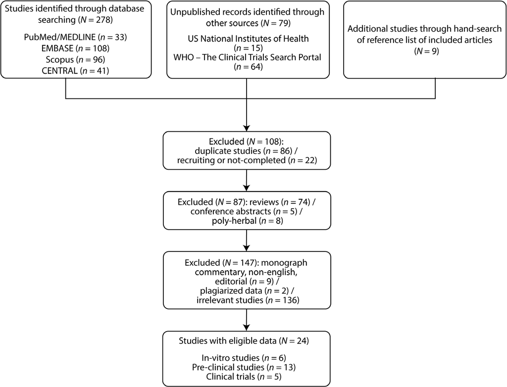

FIGURE 1

Preferred reporting items

for systematic reviews and meta-analyses

flow-chart of study selection

DURG ET AL.

1043

(150 mg/kg, ip) too showed continuous body weight loss in diabetic

rats (Udayakumar et al., 2009). Also, STZ (65 mg/kg) and nicotinamide

(120 mg/kg, 15 min after STZ) ip injection demonstrated decrease in

body weight in type-2 diabetic mice (Thakur et al., 2015). The meta-

analysis data confirmed that oral supplementation of W. somnifera

(root/leaf extract) significantly (Table 4; Figure S1) protected body

weight loss in diabetic rats/mice. Tekula and colleagues assessed the

effect of withaferin A on body weight in type-1 diabetes mice. The

study noted insignificant decrease in body weight in diabetic control

mice; supplementation of withaferin A (2 and 10 mg/kg) showed insig-

nificant

body

weight

improvement

in

diabetic

mice

(Tekula

et al., 2018).

3.4

|

Blood glucose and glycosylated haemoglobin

In experimental rats, AM/STZ injection produced significant increase

in blood glucose level depicting diabetes. The meta-analysis of

W. somnifera (root/leaf extract) effect in diabetic rats reported signifi-

cant (p < .00001; Figure 2a) reduction in blood glucose level. Parihar

and colleagues also assessed the dietary effect of W. somnifera on

blood glucose level in STZ-induced diabetic mice and rats, respec-

tively. W. somnifera treated diabetic rats and mice showed significant

(43.44%; p < .05) and numerical (31.70%) decrease in blood glucose

level (M. S. Parihar et al., 2004; P. Parihar et al., 2016). Thakur et al.

evaluated three different doses (25/50/100 mg/kg) of W. somnifera in

diabetic mice and all three doses significantly (p < .05) lowered

(27.32%/44.76%/55.81%) plasma glucose levels (Thakur et al., 2015).

Withaferin A (2 and 10 mg/kg) supplementation, in 3 and 4 weeks,

also statistically (p < .001) reduced the elevated blood glucose levels

in type-1 diabetes mice (Tekula et al., 2018). Clinical studies reported

significant reduction in fasting blood glucose level (p = .001;

Figure 2b) on W. somnifera administration. Similarly, W. somnifera sup-

plementation (root/leaf extract) significantly (p < .00001; Figure 3)

reduced elevated HbAlc levels to near normal in diabetic rats. Further,

a clinical study also observed with significant reduction in post pran-

dial blood glucose (PPBS) and HbAlc levels in patients who were on

oral hypoglycaemic agents (metformin, 500 mg + glimepride, 1 mg)

with or without W. somnifera; however, the reduction was higher

(PPBS, 29.66 vs. 25.51%; HbA1c, 13.73 vs. 9.31%) in patients receiv-

ing oral hypoglycaemic agents with W. somnifera (Nayak et al., 2015).

3.5

|

Insulin level/sensitivity and homeostasis

model assessment of insulin resistance

Anwer and colleagues reported the effect of W. somnifera on insulin

level in STZ-induced type-2 diabetic rats. STZ injection resulted in

hyperinsulinemia and treatment with W. somnifera (200 and 400 mg/

kg) statistically (p < .001) reduced (17.71 and 30.21%) the elevated

levels of insulin (Anwer et al., 2008). On the contrary, Thakur et al.

reported significantly lower levels of insulin in mice injected with STZ

(65 mg/kg) and nicotinamide (120 mg/kg, 15 min after STZ). Oral sup-

plementation of W. somnifera (50 and 100 mg/kg) in a dose-

dependent manner increased (p < .05; 32.99 and 52.57%) plasma

insulin levels (Thakur et al., 2015). Multiple low doses of STZ

(40 mg kg<sup>−</sup><sup>1</sup>day<sup>−</sup><sup>1</sup>, for 5 consecutive days) ip injection significantly

(p < .001) decreased plasma and tissue insulin levels, indicating type-1

TABLE 1

Description of included in-vitro studies

Study

Description of W. somnifera/its derivatives

Outcomes

Jonathan et al. (2015)

W. somnifera leaf and root extracts, and six purified

withanolides were prepared from dried plant material

according to the published literature

Anti-diabetic activity based on glucose uptake in

myotubes and adipocytes, insulin secretion in basal

pancreatic β-cells

Effect of elicitors (methyl salicylate and chitosan) on

anti-diabetic activity

Huerta et al. (2010)

W. somnifera was obtained from Taj imports (Austin, TX); the

extraction of low and high molecular weight W. somnifera

fraction according to the published literature

ABTS radical and TBARS formation, α-amylase

inhibition, and maltase, sucrase and lipase activities

Khan et al. (2014)

Withanolides isolated from the shade-dried whole W.

somnifera plant material according to the published

literature

α-Glucosidase inhibitory assay with IC50 values

Nirupama et al. (2014)

W. somnifera petroleum ether, benzene, chloroform, alcohol,

cold and hot water, NaOH, and aqueous crude root extract

were prepared according to the published literature

Glucose uptake/transport by yeast cells, α-amylase

inhibitory activity, glucose adsorption and diffusion

Shah et al. (2017)

W. somnifera (10 g) leaf and root powder extracted according

to the published literature

Glucose uptake assay (via 3T3 F442A fibroblast

[adipocyte] cells)

Singh et al. (2013)

Methanolic extract of W. somnifera root powder (herb: extract

5:1 w/w) was gifted (voucher specimens, WS -1,142) by

Amasar Pvt. Ltd, Indore, India

DPP-IV enzyme assay

DPPH scavenging assay

Total phenolics content

Antioxidant activity

Reducing power

Abbreviations: ABTS, azinobis 3-ethyl-benzothiazoline-6-sulfonic acid; DPP-IV, dipeptidyl peptidase-IV; DPPH, 2,2-diphenyl-1-picrylhydrazyl; TBARS,

thiobarbituric acid reactive substances.

1044

DURG ET AL.

TABLE 2

Description of included pre-clinical studies

Study ID

Diabetes inducing

agent (dose

mg/kg

b.w, route)

Description of W. somnifera/its

derivatives

Dose (route)

Duration

of treatment

Experimental design

Parameters studied

Anwer et al.

(2008)

STZ (100

mg/kg, ip)

Standardized powdered, aqueous

root extract of W. somnifera

(batch no. WS/05002;

withanolides, 3.9% w/w) was

gifted by Natural Remedies,

Bangalore, India

200 and

400 mg/kg

(oral)

5 weeks

Albino Wistar rats (N = 30); five

groups (each containing six rats)

Group 1; normal control (citrate

buffer 0.1 ml/10 g, ip): Group 2;

diabetic control (single dose of

STZ): Group 3; single dose of STZ

+ W. somnifera (200 mg/kg):

Group 4; single dose of STZ

+ W. somnifera (400 mg/kg):

Group 5; only W. somnifera

(400 mg/kg)

Blood glucose, HbA1c, insulin level, oral

glucose tolerance test and insulin

sensitivity

Anwer et al.

(2012)

STZ (100

mg/kg, ip)

Standardized powdered, aqueous

root extract of W. somnifera

(batch no. WS/05002;

withanolides, 3.9% w/w) was

gifted by Natural Remedies,

Bangalore, India

200 and

400 mg/kg

(oral)

5 weeks

Albino Wistar rats (N = 24); four

groups (each containing six rats)

Group 1; normal control (citrate

buffer): Group 2; diabetic control

(single dose of STZ): Group 3;

single dose of STZ + W. somnifera

(200 mg/kg): Group 4: Single dose

of STZ + W. somnifera (400 mg/

kg)

Blood glucose, oxidative stress markers

(MDA [a secondary product of LPO], GSH,

GPx, GR, GST, SOD and CAT) and

histopathological examination of pancreas

Anwer et al.

(2017)

STZ (100

mg/kg, ip)

Aqueous root extract of W.

somnifera (batch no. WS/05002;

withanolides, 3.9% w/w) was

gifted by natural remedies,

Bangalore, India

200 and 400 mg/

kg

5 weeks

Albino Wistar rats (N = 30); five

groups (each containing six rats)

Group 1; normal control (citrate

buffer, 0.1 ml/kg, ip): Group 2;

diabetic control (single dose of

STZ); Group 3; only W. somnifera

(400 mg/kg): Group 4; single dose

of STZ + W. somnifera (200 mg/

kg): Group 5; single dose of STZ

+ W. somnifera (400 mg/kg)

Blood glucose, lipid profile (TC, TG, HDL-C,

LDL-C, and VLDL-C), serum markers (LDH

and CK), oxidative stress markers (MDA

[a secondary product of LPO], GSH, GPx,

GR, GST, SOD and CAT), and protein

(in heart)

Jain et al.

(2006)

STZ (60

mg/kg, ip)

Alcoholic root extract of W.

somnifera (1.5% withanolides)

procured from Sanat Products,

New Delhi, India

20 mg/kg

3 weeks

Sprague–Dawley rats (150–200 g)

of either sex (N = 42); seven

groups (each containing six rats)

Group 1; diabetic control: Group 2;

W. somnifera (20 mg/kg): Group 3;

A. sativum (100 mg/kg): Group 4;

G. sylvestre (100 mg/kg): Group 5;

F. foetida (100 or 200 mg/kg):

Fasting blood glucose

Blood glucose

(Continues)

DURG ET AL.

1045

TABLE 2

(Continued)

Study ID

Diabetes inducing

agent (dose

mg/kg

b.w, route)

Description of W. somnifera/its

derivatives

Dose (route)

Duration

of treatment

Experimental design

Parameters studied

Group 6; M. koenigii (200 mg/kg):

Group 7; insulin

Kiasalari et al.

(2009)

STZ (60

mg/kg, ip)

W. somnifera root was procured

from the local market, then

powdered and mixed in pelleted

food at ratio of 6.25%

W. somnifera

powdered

root-mixed

pelleted

food at ratio of

6.25%

4 weeks

Adult male (195–220 g) Wistar rats

(N = 39); four groups

Group 1 (n = 8); normal control (W.

somnifera, 4 weeks): Group

2 (n = 11); sham: Group 3 (n = 9);

diabetic control: Group 4 (n = 11);

single dose of STZ + W. somnifera

Serum sexual hormone levels (estrogen,

progesterone, FSH, LH and testosterone),

serum glucose, cholesterol and triglyceride

levels

Kyathanahalli

et al. (2014)

STZ (90

mg/kg, ip)

Standard root extract of W.

somnifera powder (batch number:

C81015; anolides, 2.57%;

aferin A, 2.38%) was procured

from M/s Sami Labs Ltd.,

Bangalore, India

The major active principles: Anolides

(steroidal alkaloids and steroidal

lactones) with glycosides, starch,

and variety of amino acids in trace

quantities

500 mg/kg (oral)

15 days

Four weeks old prepubertal male

(40 ± 5 g) CFT-Wistar rats

(N = 18); three groups (each

containing six rats)

Group 1; normal control: Group 2;

diabetic control (single dose of

STZ): Group 3; single dose of STZ

+ W. somnifera (500 mg/kg)

Total polyphenol and flavonoid content

analysis

In-vitro: Anti-oxidant and free radical

scavenging activity (DPPH, HOCl and

hydroxyl radicals)

In-vivo: Body weight, organ weights (testis

and liver), plasma glucose, testicular

oxidative stress markers (ROS, LPO, GSH,

SOD, GPx, GST, GR, G6PDH, LDH, CAT

and 3β-HSD), testis glutathione, total thiol

and nonprotein thiol

M. S. Parihar

et al. (2004)

STZ (60

mg/kg, ip)

Methanolic fraction of W. somnifera

root extract was prepared

according to the published

research study

20 mg/kg (oral)

1 month

Female (25 g) Swiss albino mice

(N = 40); five groups (each

containing eight mice)

Group 1; normal control: Group 2;

diabetic control (single dose of

STZ): Group 3; single dose of STZ

+ W. somnifera (20 mg/kg): Group

4; single dose of STZ + Aloe vera

(32 mg/kg): Group 5; single dose

of STZ + combination of W.

somnifera and aloe vera

LPO and protein carbonyl in hippocampus

and cerebral cortex, blood glucose, total

protein content in brain homogenates, iron

reducing activity of extracts and behavioral

test (motor and memory performance)

P. Parihar

et al. (2016)

STZ (60

mg/kg, ip)

Same as M. S. Parihar (2004)

35 mg/kg (oral)

30 days

Adult (250–300 g) male Wistar rats

(N = 40); four groups (each

containing 10 rats)

Group 1; normal control: Group 2;

W. somnifera (35 mg/kg): Group 3;

diabetic control (single dose of

STZ): Group 4; single dose of STZ

+ W. somnifera (35 mg/kg)

Total anti-oxidant activity of extract (ferric

[Fe3+] reducing anti-oxidant power and

ferrozine assay), total protein content of

hypothalamus tissue homogenates, LPO

and protein carbonyl in hippocampus, GSH,

GPx, mitochondrial permeability transition,

blood glucose

(Continues)

1046

DURG ET AL.

TABLE 2

(Continued)

Study ID

Diabetes inducing

agent (dose

mg/kg

b.w, route)

Description of W. somnifera/its

derivatives

Dose (route)

Duration

of treatment

Experimental design

Parameters studied

Sarangi

et al. (2013)

STZ (150

mg/kg, ip)

Root and leaf extract of W.

somnifera were prepared

according to the published

research study

200 mg/kg (oral)

8 weeks

Adult (150–180 g) male albino

Wistar rats (N = 24); four groups

(each containing six rats)

Group 1; normal control (distilled

water): Group 2; diabetic control

(single dose of STZ): Group 3;

single dose of STZ + W. somnifera

root extract (200 mg/kg): Group

4; single dose of STZ

+ W. somnifera leaf extract

(200 mg/kg)

Blood glucose, lipid profile (TC, TG, HDL-C,

and LDL-C), serum enzymes (AST, ALT,

ALP and LDH), total protein, albumin,

globulin and A:G ratio

Tekula et al.

(2018)

STZ (40

mg/kg, ip)

Withaferin A (>98% pure) was

purchased from Aptus

therapeutics, Hyderabad, India

(characterized by NMR and FTIR

spectroscopy for integrity)

2 and 10 mg/kg

(oral)

4 weeks

Male Swiss albino mice (N = 40); five

groups (each containing eight

mice)

Group 1; normal control: Group 2;

diabetic

Control (multiple low dose of STZ)

+ vehicle: Group 3; drug control

(WA per se) which were treated

with 10 mg/kg WA alone: Group

4; MLD-STZ + WA (2 mg/kg):

Group 5: MLD-STZ + WA

(10 mg/kg)

Body weight, blood glucose, intraperitoneal

glucose tolerance test, pancreatic oxidative

and nitrosative stress

Plasma and tissue inflammatory cytokine

levels, plasma and tissue insulin estimation

Nuclear p65-NFκB levels in pancreatic

tissues, histopathology and insulitis scoring

Immunohistochemistry, TUNEL assay

Thakur et al.

(2015)

STZ (65

mg/kg, ip)

Methanolic extract prepared from

root of W. somnifera according to

the published research study

10 days

Adult male (25 ± 5 g) albino mice

(N = 30); five groups (each

containing six mice)

Group 1: Normal control; Group 2:

Diabetic control (single dose of

STZ + vehicle only); Group 3:

Single dose of STZ + W. somnifera

(25 mg/kg); Group 4: Single dose

of STZ + W. somnifera (50 mg/kg);

Group 5: Single dose of STZ + W.

somnifera (100 mg/kg)

Body weight, basal rectal temperature, foot

shock stress-triggered transient hyper-

thermia, organ weights (adrenal glands and

spleen), plasma glucose, insulin, cortisol

levels

Udayakumar

et al. (2009)

Alloxan

(150 mg/kg, ip)

Root and leaf extract of W.

somnifera were prepared

according to the published

research study

100 and 200 mg/

kg (oral)

8 weeks

Male (150–180 g) albino Wistar rats

(N = 42) seven groups (each

containing six rats)

Group 1; normal control (distilled

water): Group 2; diabetic control

Body weight, urine sugar, blood glucose, Hb,

HbA1c, liver glycogen, lipid profile (TC, TG,

PL, HDL-C, LDL-C and VLDL-C), tissue

lipids (heart, liver and kidney; TC, TG and

PL), serum protein (total protein, albumin

(Continues)

DURG ET AL.

1047

TABLE 2

(Continued)

Study ID

Diabetes inducing

agent (dose

mg/kg

b.w, route)

Description of W. somnifera/its

derivatives

Dose (route)

Duration

of treatment

Experimental design

Parameters studied

(single dose of alloxan): Group 3;

single dose of alloxan +

W. somnifera root extract

(100 mg/kg): Group 4; single dose

of alloxan + W. somnifera root

extract (200 mg/kg): Group 5;

single dose of alloxan +

W. somnifera leaf extract (100 mg/

kg): Group 6; single dose of

alloxan + W. somnifera leaf extract

(200 mg/kg): Group 7; single dose

of alloxan + glibenclamide

(0.6 mg/kg)

and globulin), tissue protein (heart, liver

and kidney), liver G6P, serum enzymes

(AST, ALT, ACP and ALP)

Udayakumar

et al. (2010)

Alloxan

(150 mg/kg, ip)

Root and leaf extract of W.

somnifera were prepared

according to the published

research study

100 and 200

mg/kg (oral)

8 weeks

Male (150–180 g) albino Wistar rats

(N = 42); seven groups (each

containing six rats)

Group 1; normal control (distilled

water): Group 2; diabetic control

(single dose of alloxan): Group 3;

single dose of alloxan +

W. somnifera root extract

(100 mg/kg): Group 4; single dose

of alloxan + W. somnifera root

extract (200 mg/kg): Group 5;

single dose of alloxan +

W. somnifera leaf extract (100 mg/

kg): Group 6; single dose of

alloxan + W. somnifera leaf extract

(200 mg/kg): Group 7; single dose

of alloxan + glibenclamide

(0.6 mg/kg)

Urine sugar, blood glucose, liver glycogen,

liver, kidney and heart antioxidants (SOD,

LPO, CAT, GPx, GSH, GST), plasma vitamin

C and E

Note: N = total number of animals in the study; n = total number of animals in a group.

Abbreviations: A:G ratio, albumin:globulin; 3β-HSD, 3 β-hydroxysteroid dehydrogenase; ACP, acid phosphatase; ALP, alkaline phosphatase; ALT, alanine transaminase; AST, aspartate transaminase; CAT,

catalase; CK, creatinine kinase; DPPH, diphenyl-2-picryl-hydrazil; FSH, follicle stimulating hormone; FTIR, fourier-transform infrared; GPX, glutathione peroxidise; G6PDH, glucose 6-phosphate dehydrogenase,

GSH, glutathione; GST, glutathione-S-transferase; GR, glutathione reductase; HbA1c, glycosylated haemoglobin; HDL, high-density lipoprotein; HOC1, hypochlorous acid; HOMA-IR, homeostasis model

assessment of insulin resistance; LDH, lactate dehydrogenase; LDL, low-density lipoprotein; LH, luteinizing hormone; LPO, lipid peroxidation; MDA, malondialdehyde; MLD, multiple low dose; NFκB, nuclear

factor kappa-light-chain-enhancer of activated B cells; NMR, nuclear magnetic resonance; PL, phospholipids; ROS, reactive oxygen species; SOD, superoxide dismutase; STZ, streptozotocin; TC, total cholesterol;

TG, triglyceride; TUNEL, terminal deoxynucleotidyl transferase-mediated dUTP nick end labeling; VLDL, very low-density lipoprotein.

1048

DURG ET AL.

diabetic profile. The intervention of withaferin A in type-1 diabetes

mice demonstrated significant increase (p < .001) to near normal in

plasma (2 and 10 mg/kg) and tissue (10 mg/kg) insulin levels (Tekula

et al., 2018). Further, the levels of homeostasis model assessment of

insulin resistance (HOMA-IR; an index of hepatic insulin resistance)

and KITT (an index of peripheral insulin resistance) were assessed;

W. somnifera (200 and 400 mg/kg) significantly restored the HOMA-

IR (p < .001; 61.37 and 73.87%) and KITT (p < .001; 33.34 and 75.56%)

levels in diabetic rats (Anwer et al., 2008).

3.6

|

Lipid profile

Induction of diabetes by AM/STZ in experimental rats produced ele-

vated lipid profile such as total cholesterol (TC), triglyceride (TG), low-

density lipoprotein (LDL) and very low-density lipoprotein (VLDL)

besides decrease in high-density lipoprotein (HDL) levels. Administra-

tion of W. somnifera root/leaf extract significantly restored altered

lipid profile to near normal (Table 4; Figures S2–S6). AM-induced dia-

betes also noted with elevated levels of TC, TG and phospholipids in

heart, liver and kidney which were lowered to near normal on

W. somnifera treatment (Figure S7; Udayakumar et al., 2009). Clinical

evidence also corroborated with experimental data showing signifi-

cantly improved lipid profile with W. somnifera treatment (Figure 4a;

vs. active control/placebo: Figure 4b; vs. pre-treatment; Andallu &

Radhika, 2000; Nayak et al., 2015; Usharani, Fatima, et al., 2014;

Usharani, Kishan, et al., 2014).

3.7

|

Serum markers

Levels of aspartate aminotransferase (AST), alanine aminotransferase

(ALT) and alkaline phosphatase (ALP) were elevated in experimental

diabetic rats which were reduced to near normal with W. somnifera

treatment (Table 4; Figures S8–S10). Similarly, W. somnifera root

(28.93%) and leaf (31.53%) extracts significantly decreased the ele-

vated levels of acid phosphatase (Udayakumar et al., 2009). Induction

of diabetes in experimental rats significantly reduced serum total pro-

tein, albumin, albumin:globulin (A:G) ratio and liver glycogen which

were statistically improved after administration of W. somnifera root/

leaf extract (Table 4; Figures S11–S14).

3.8

|

OS markers

Injection of AM/STZ in experimental rats significantly reduced endog-

enous antioxidant levels, such as superoxide dismutase (SOD), cata-

lase

(CAT),

glutathione

(GSH),

glutathione

peroxidase

(GPx),

glutathione S-transferase (GST) and glutathione reductase (GR) in the

myocardial, hepatic and kidney as well pancreatic (only GPx, GST and

GR) tissues and administration of W. somnifera root/leaf extract

restored decreased levels close to normal. Further, increased lipid per-

oxidation (LPO)/TBARS (n mole malondialdehyde [MDA]/mg protein)

level in the myocardial, hepatic, pancreatic and kidney tissues of dia-

betic rats reduced statistically with W. somnifera treatment (Table 4;

Figures S15–S21).

Induction of diabetes in prepubertal rats significantly elevated;

reactive oxidative species (ROS) generation (120%; in both testis cyto-

sol and mitochondria), membrane LPO (66%; in both testis cytosol

and mitochondria), GSH (cytosol, less altered; mitochondria, 22%),

SOD (cytosol, less altered; mitochondria, 53%), GST and GR (in both

testis cytosol and mitochondria): decreased total thiol concentration

(cytosol, 43%; mitochondria, 16%) and CAT (Kyathanahalli et al.,

2014).

Supplementation

of

W.

somnifera

(15 days)

statistically

restored diabetes-induced testicular oxidative impairments. Further,

W. somnifera administration significantly restored the altered activities

of lactate dehydrogenase (LDH), glucose 6-phosphate dehydrogenase

(G6PDH) and β-hydroxysteroid dehydrogenase (3β-HSD) to near nor-

mal. Two studies noted with significant decrease in LDH levels after

W. somnifera root/leaf extract treatment (Anwer et al., 2017; Sarangi

et al., 2013). Diabetic rats also observed with statistical decrease in

elevated levels of serum marker enzyme, creatinine kinase (CK), when

treated with W. somnifera root extract (Anwer et al., 2017). Parihar

et al. noticed that induction of diabetes in mice/rat significantly

(p < .05) increased LPO and protein carbonyl (PC) in hippocampus/

hypothalamus and cerebral cortex brain regions (M. S. Parihar et al.,

2004; P. Parihar et al., 2016). Supplementation of W. somnifera in dia-

betic mice/rat significantly (p < .05) reduced LPO and PC in the ana-

lyzed brain regions. Further, W. somnifera also significantly (p < .05)

stabilized GSH and GPx levels to near normal in the hypothalamus

(P. Parihar et al., 2016). AM injection significantly (p < .05) increased

liver glucose-6-phosphatase (G6P; 220%) and ALP (124%) levels and

treatment with W. somnifera root/leaf extract significantly restored

these (G6P; 55%/52%: ALP; 84%/85%) altered levels (Udayakumar

et al., 2009). Tekula et al. also noted increased (p < .05) MDA and

nitrosative stress levels in type-1 diabetes mice (Tekula et al., 2018).

Supplementation with withaferin A: documented with 3 and 4.1 folds

decrease in MDA levels at 2 and 10 mg/day, respectively; prevented

(both doses) the elevation of tissue nitrosative stress; lowered tissue

nitrite levels (2 mg/kg, p < .001; 10 mg/kg, p < .01). In two RCTs, sup-

plementation of W. somnifera root extract (250 and 500 mg) in

patients with type-2 diabetes significantly (p ≤ .05) increased GSH

and nitric oxide (NO) levels and decreased MDA and high-sensitivity

C-reactive

protein

(hs-CRP;

an

inflammatory

biomarker)

levels

(Usharani, Fatima, et al., 2014; Usharani, Kishan, et al., 2014).

3.9

|

Other biochemical parameters

W. somnifera root extract was evaluated for oral glucose tolerance test

(OGTT) in experimental rats after oral supplementation of glucose

(2 g/kg), Figure S22 (Anwer et al., 2008). In type-2 diabetes rats, there

was significant (p < .001) increase in blood glucose level from baseline

to 120 min. W. somnifera treatment (200 and 400 mg/kg) statistically

(p < .001) decreased blood glucose level at all intervals during OGTT.

Experimental

rats treated with

only W.

somnifera showed no

DURG ET AL.

1049

significant difference in blood glucose level at 60 and 120 min (Anwer

et al., 2008). Anwer et al. observed the histopathological changes in

diabetic and control rats. Experimental rats treated with citrate buffer

(pH 4.5) showed normal pancreatic acini and β-cells of islets of

Langerhans. However, STZ-induced type-2 diabetes rats observed

with degenerative and lytic changes in the pancreatic islets of

Langerhans and depletion of β-cells in addition to reduced dimension

and, shrunken of the islet. Supplementation of W. somnifera restored

the histological changes of pancreas to near normal—as evident from

increased size and number of β-cells (Anwer et al., 2012).

Withaferin A (2 and 10 mg/kg) significantly (p < .05) reduced

inflammatory cytokines, that is, IL-6 and TNF-α in type-1 diabetes

mice (Tekula et al., 2018). Furthermore, withaferin A (10 mg/kg) statis-

tically decreased cytosolic (p < .05) and nuclear (p < .001) levels of

p65-NFκB. Withaferin A was also observed with improved insulitis

scoring and pancreatic islets morphology, in addition to reduced DNA

fragmentation and apoptosis due to diabetes. Supplementation of

type-1 diabetes mice with withaferin A (p < .001; 10 mg/kg) addition-

ally noted with enhanced/reduced expression of Nrf2/NFκB, further

indicating its contributory antioxidant role in W. somnifera activity.

W. somnifera root extract supplementation for 10 days signifi-

cantly inhibited (25 mg, −7.14%; 50 mg, −17.53%; 100 mg, −30.52%)

the elevated cortisol levels in diabetic mice (Thakur et al., 2015).

Induction of diabetes in rats was observed with significant reduction

in plasma vitamins C and E levels which were restored to near normal

after treatment with W. somnifera root (73.19%) and leaf (54.35%)

extracts, indicating its convincing antioxidant potential (Udayakumar

et al., 2010).

Usharani and colleagues, in patients with type-2 diabetes, mea-

sured the effect of W. somnifera in endothelial dysfunction (measured

somnifera

(250

and

500 mg)

showed

significant

(p < .001) change in RI (Usharani, Fatima, et al., 2014); in another

study, W. somnifera at 500 mg significantly (p < .001) improved RI

(Usharani, Kishan, et al., 2014).

3.10

|

Safety and tolerability

Of five included clinical studies, three measured the safety and tolera-

bility of W. somnifera in patients with type-2 diabetes and reported no

safety

concerns

from

evaluated

laboratory

parameters

(i.e., haematological, renal and hepatic; Nayak et al., 2015; Usharani,

Fatima, et al., 2014; Usharani, Kishan, et al., 2014). Further, Raut et al.

assessed the safety and tolerability of W. somnifera in 18 healthy vol-

unteers, and noted significant reduction in TC and LDL with decreas-

ing trend in TG, and increase in muscle strength activity (Raut et al.,

2012). The organ function tests were normal after W. somnifera inter-

vention and escalated doses (750–1,250 mg/day) were well tolerated.

Similarly, in two RCTs, supplementation of W. somnifera in healthy

young adults (of either sex; 500 mg/day) and aging overweight males

(two tablets/day; each tablet containing 10.5 mg of withanolide glyco-

sides) for 8 weeks noted to be safe with well tolerance (Lopresti,

Drummond, & Smith, 2019; Sandhu et al., 2010). The systematic eval-

uation of W. somnifera by Mishra, Venkatachalapathy, & Khanli (2017)

also reported with no significant safety concerns. Furthermore, the

control group (experimental animals)—from 13 pre-clinical included

studies, showed no adverse effects. Additionally, a sub-acute toxicity

study

with

W.

somnifera

having

4.5%

of

withaferin

A

(2,000 mg kg<sup>−</sup><sup>1</sup>day<sup>−</sup><sup>1</sup>) confirmed no adverse effects in experimental

rats (Patel, Rao, & Hingorani, 2016). Besides all these, W. somnifera

has a long history of safe use (HoSU) data (D. Narayana &

Durg, 2019).

4

|

DISCUSSION

To the facts, this is the first systematic review and meta-analysis eval-

uating

the

efficacy/effectiveness,

safety

and

tolerability

of

W. somnifera treatment in DM. Of 13 pre-clinical studies, four studies

investigated effect of W. somnifera in type-2 diabetes rats (Anwer

et al., 2017, 2008, 2012; Thakur et al., 2015), three studies in type-1

diabetes rats (Jain et al., 2006; Kiasalari et al., 2009; Tekula et al.,

2018) and the remaining studies did not mention about the type of

diabetes condition (Kyathanahalli et al., 2014; M. S. Parihar et al.,

2004; P. Parihar et al., 2016; Sarangi et al., 2013; Udayakumar et al.,

2009, 2010). However, by virtue of their pancreatic β-cell reduction/

toxicity by AM/STZ, these studies mimicked either type-1 or type-2

diabetes or both conditions (Durg, Veerapur, Neelima, & Dhadde,

2017). Clinical trials mainly evaluated the role of W. somnifera root

extract in controlling type-2 diabetes and its related symptoms.

Induction of diabetes by AM leads to selective necrosis of pancre-

atic β-cells via inhibition of glucokinase resulting in insulin resistance

and generation of ROS (Lenzen, 2008). In case of STZ, there is libera-

tion of NO leading to aconitase inhibition thus causing pancreatic

β-cell toxicity (via alkylation of DNA) which ultimately inhibits insulin

secretion causing diabetes (Lenzen, 2008; Szkudelski, 2001). These

actions, together, lead to impaired antioxidant defense mechanism in

the pancreatic β-cells, and thus causing OS which lead to β-cell secre-

tory pathway dysfunction and insulin resistance (Hasnain, Prins, &

McGuckin, 2016; Tangvarasittichai, 2015). It is also implicated as the

underlying cause of both micro- and macro-vascular diabetes compli-

cations (Giacco & Brownlee, 2010). Therapeutic interventions that

intercept OS may delay and/or prevent the progression and onset of

DM (Hasnain et al., 2016; Tangvarasittichai, 2015).

W. somnifera, an adaptogen, as Rasayanas (rejuvenating tonic)

with a potent antioxidant activity which promote health and longevity

by resisting the stress related to physical, chemical or biological. In-

vitro

studies

apparently

demonstrated

antioxidant

activity

of

W. somnifera by its potential in scavenging DPPH, HOCl and hydroxyl

experimental studies showed protective action of W. somnifera against

OS by significantly increasing the levels of antioxidant enzymes such

as SOD, CAT, GSH, GPx, GST and GR in diabetic rats (Anwer et al.,

2017; Udayakumar et al., 2010). W. somnifera supplementation also

significantly elevated decreased levels of vitamin C (a major water-

1050

DURG ET AL.

TABLE 3

Description of included clinical studies

Study design

Study ID

Participants/inclusion criteria

Age (years; mean ± SD)

Total sample size

(gender; M/F)

Description of W. somnifera

Treatment(s) groups and dosage

Outcomes

Andallu &

Radhika,

(2000)

Mild hyperglycemic (NIDDM) and

hypercholesterolemic

40–60a

Observational study

N = 12b

Dried roots of W. somnifera were

collected from IMPCOPS (Indian

medical Practitioner's cooperative

society), powdered and filled in

capsules to make 500 mg

W. somnifera group (n = 6): 500 mg

capsule (6 capsules/day, 2 after

every meal) for 30 days

Control group (n = 6): Oral

hypoglycemic drug (daonil) for

30 days

Blood glucose, sodium

and potassium in

serum and urine,

urine volume, and

lipid profile (TC, TG,

HDL-C, LDL-C and

VLDL-C)

Agnihotri

et al.

(2013)

Schizophrenia patients, suffering

from metabolic syndrome, on

second-generation

Antipsychotics for 6 months or

more, with FBG level >100 mg/dl,

serum TGs >150 mg/dl, HDL-C

<40 mg/dl in men and <50 mg/dl

in women

>18a

Randomised, double-

blind, placebo-

controlled trial

N = 25b

W. somnifera extract (cap Strelaxin,

manufactured by M/s

Pharmanza Herbal Pvt. Ltd. Gujarat,

India) containing 400 mg of W.

somnifera extract per capsule

W. somnifera extract group (n = 12):

400 mg of W. somnifera extract

per capsule, one capsule TID for

1 month

Placebo group (n = 13): Matching

placebo to W. somnifera extract,

one capsule TID for 1 month

Body weight, FBG and

lipid profile (TG and

HDL-C), blood

pressure

Nayak et al.

(2015)

T2DM patients treated with fixed

OHAs (metformin, 500 mg

+ glimepride, 1 mg),

FBS ≥126 and ≤180 mg/dl, PPBS

≤240 mg/dl, HbA1C ≥7%, and

mean total DDS scoring ≥3

21–70a

Randomised clinical trial

N = 55b

Soft gelatine W. somnifera capsules

containing 300 mg of root extract

in ground nut oil base

manufactured by Dabur India Ltd.

W. somnifera group (n = 28): Capsule

of 300 mg root extract in ground

nut oil base, one capsule BID with

a cup of Luke warm milk for

6 weeks

Control group (n = 27): Soft gelatine

capsule of only ground nut oil, one

capsule BID with a cup of Luke

warm milk for 6 weeks another

6 weeks, the patients were

followed-up

DDS17 score

(emotional burden,

physician related

distress, regimen

related distress, and

interpersonal

distress), FBS, PPBS,

HbA1c, lipid profile

(TC) and adverse

events

Usharani,

Fatima,

et al.

(2014)

T2DM patients with

FBG between 110–126 mg/dl,

HbA1c between 6.5 and 8.0%, on

oral hypoglycemic agents for last

8 weeks (metformin,

1,500–2,000 mg/day) prior to

screening visit, endothelial

dysfunction defined as ≤6%

change in reflection index (RI) on

post salbutamol challenge test

W. somnifera (250 mg):

55.40 ± 8.07

W. somnifera (500 mg):

57.30 ± 9.40

Placebo: 57.45 ± 8.85

Randomised, double-

blind, placebo-

controlled, parallel

design trial

N = 60

W. somnifera (250 mg):

n = 20; 14/6

W. somnifera (500 mg):

n = 20; 13/7

Placebo: n = 20; 12/8

SENSORIL®: An aqueous root

extract of W. somnifera, containing

not less than 10% with anolide

glycosides, not more than 0.5% of

withaferin-A and not less than

32% of oligosaccharides

W. somnifera group (n = 20): Capsule

of 250 mg root extract BID for

12 weeks

W. somnifera group (n = 20): Capsule

of 500 mg root extract BID for

12 weeks

Placebo (n = 20): Identical matching

capsule to W. somnifera BID for

12 weeks

Endothelial dysfunction

(RI), oxidative stress

biomarkers (NO,

MDA, GSH and hs-

CRP), lipid profile

(TC, TG, HDL-C,

LDL-C and VLDL-C),

safety and

tolerability

Usharani,

Kishan,

T2DM patients with

FBG ≥110 mg/dl, HbA1c between

6.5 and 8.0%, on oral

somnifera (250 mg):

60.10 ± 6.47

Prospective, randomised,

double-blind, parallel

group trial

Same as Usharani, Fatima, et al.

(2014)

W. somnifera (n = 10): Capsule of

250 mg root extract BID for

12 weeks

Endothelial dysfunction

(RI), oxidative stress

biomarkers (NO,

(Continues)

DURG ET AL.

1051

soluble non-enzymatic antioxidant) and E (a chain-breaking antioxi-

dant) in diabetic rats (Udayakumar et al., 2010), thus showing strong

antioxidant defense mechanism of W. somnifera. Likewise, the antioxi-

dant effects of W. somnifera were also evidenced in clinical studies;

increase in NO and GSH levels (Usharani, Fatima, et al., 2014;

Usharani, Kishan, et al., 2014). The environment of OS causes exces-

sive generation of ROS, viz., superoxide anion, hydrogen peroxide and

hydroxyl radicals which induce LPO (toxic peroxide product) of cell

membrane lipids leading to cellular and molecular damage (Durg et al.,

2015). In the present analysis, diabetic rats were noted with increased

LPO levels in heart, liver, pancreas and kidney tissues which were

decreased after supplementation of W. somnifera. Treatment of

hypercholesteremic rats with W. somnifera were also noted with sig-

nificant decrease in LPO levels (Visavadiya & Narasimhacharya, 2007).

Similarly, W. somnifera decreased MDA (a secondary product of LPO)

levels in patients with type-2 diabetes (Usharani, Fatima, et al., 2014;

Usharani, Kishan, et al., 2014). The observed antioxidant activities of

W. somnifera might be, majorly, attributed to its active constituent

withaferin A—a steroidal lactone (Aliper et al., 2017; Lee et al., 2016)

as well other bioactive elements—steroidal alkaloids/lactones such as

withanine,

somniferine,

withanone

sitoindosides

VII–X

and

withanolide A, D and G (Durg et al., 2015; Mirjalili, Moyano, Bonfill,

Cusido, & Palazón, 2009).

Induction of diabetes by AM/STZ in experimental rats signifi-

cantly increased blood glucose and HbA1c levels. The meta-analysis

of W. somnifera supplementation in these diabetic rats significantly

reduced blood glucose and HbA1c; similarly, in patients with type-2

diabetes, W. somnifera significantly reduced fasting blood glucose

level (Agnihotri et al., 2013; Nayak et al., 2015). Additionally, isolated

constituents of W. somnifera root extract noticed to inhibit stress-

induced hyperglycemia by blocking corticosterone hypersecretion in

experimental stressed rats (Sarjan & Yajurvedi, 2018). The supportive

mechanism(s) of action(s) of W. somnifera for the observed anti-

diabetic activity are depicted in Figure 5. The observed anti-

hyperglycaemic activity of W. somnifera might be attributed to multi-

ple mechanisms such as β-cell protection (preserve the size and num-

ber of β-cells) from OS (Anwer et al., 2012), rejuvenation and

activation of pancreatic β–cells leading to insulin release (Udayakumar

et al., 2010). W. somnifera also acts by inhibiting α-glucosidase,

α-amylase and DPP-IV enzymes (Huerta et al., 2010; Khan et al.,

2014; Singh et al., 2013). It also stimulates glucose transports which

further accelerates transport of glucose into cells (Nirupama et al.,

2014). Further, the bioactive constituents from W. somnifera extract,

that

is,

withanolides

reported

to

increase

glucose

uptake

in

myotubes and adipocytes (Jonathan et al., 2015). W. somnifera also

showed glucose lowering activity through insulinotropic effects

which improves insulin sensitivity by reducing hyperinsulinemia and

insulin resistant besides improving glucose tolerance (Anwer et al.,

2008). The recent in-silico screening revealed that withaferin A

mimics the anti-aging properties of mTOR inhibitors, that is, metfor-

min and rapamycin (Aliper et al., 2017); the two FDA-approved

drugs which tops the list of drugs mimicking caloric restriction

(Ingram et al., 2004). Further, Lee et al. demonstrated withaferin A

TABLE 3

(Continued)

Study design

Study ID

Participants/inclusion criteria

Age (years; mean ± SD)

Total sample size

(gender; M/F)

Description of W. somnifera

Treatment(s) groups and dosage

Outcomes

et al.

(2014)

hypoglycemic agents for last

8 weeks (metformin,

1,500–2,000 mg/day) prior to

screening visit, endothelial

dysfunction defined as ≤6%

change in reflection index (RI) on

post salbutamol challenge test

Phyllanthus emblica

(250 mg): 58.60

± 10.54

Combination of

Phyllanthus emblica

+ W. somnifera: 57.30

± 9.23

N = 30

W. somnifera (250 mg):

Phyllanthus emblica

(250 mg): n = 10; 9/1

Combination of

Phyllanthus emblica

+ W. somnifera (n = 10):

n = 10; 9/1

Phyllanthus emblica (n = 10): Capsule

of 500 mg BID for 12 weeks

Combination of Phyllanthus emblica

+ W. somnifera (n = 10): Capsule

of 250 mg + 250 mg BID for

12 weeks

MDA, GSH and hs-

CRP), lipid profile

(TC, TG, HDL-C, and

LDL-C), and safety

and tolerability

Note: N = total number of subjects in the study; n = total number of subjects in a group.

Abbreviations: BID, two times daily; DDS, diabetes distress scale; FBS, fasting blood; GSH, glutathione; HbA1C, glycosylated haemoglobin; HDL, high-density lipoprotein; hs-CRP, high sensitivity C-reactive

protein; LDL, low-density lipoprotein; M/F, male/female; MDA, malondialdehyde; NIDDM, non-insulin dependent diabetes mellitus; NO, nitric oxide; OHAs, oral hyoglycemic agents; PPBS, post prandial blood

sugar; RI, reflection index; T2DM, type-II diabetes mellitus; TC, total cholesterol; TG, triglyceride; TID: three times daily; VLDL, very low-density lipoprotein.

aMean ± SD values were not mentioned.

bThe distribution of male and female were not mentioned.

1052

DURG ET AL.

as a potential leptin sensitizer with great anti-diabetic effects in

mice (Lee et al., 2016).

Lipid profile abnormality is evident in diabetes which increases

the risks of atherosclerosis and coronary heart diseases (Krauss,

2004). The elevated lipid levels are result of altered oxidative metabo-

lism which leads to increased LPO in diabetes (de Souza Bastos et al.,

2016; Tangvarasittichai, 2015). Furthermore, impaired lipid metabo-

lism and LPO leads to release of proinflammatory markers such as IL-

1β, IL-6, IL-8 and TNF-α; these markers cause complications such as

retinopathy and nephropathy (de Souza Bastos et al., 2016). In addi-

tion, hyper-sensitive C-reactive protein (hs-CRP), another inflamma-

tory marker, can be a risk factor for endothelial dysfunction and

cardio-cerebrovascular events (Fan et al., 2018; Usharani, Fatima,

et al., 2014; Usharani, Kishan, et al., 2014).

Induction

of

diabetes

in

experimental

animals

significantly

increased TC, TG, LDL, and VLDL, and decreased HDL levels which

were restored to near normal with W. somnifera treatment. Similar

observations were validated in clinical trials in patients with type-2

diabetes. The hypolipidemic activity of W. somnifera can be explained

by its activity to mobilize LDL for synthesizing bile acid to remove

excess body cholesterol (Visavadiya & Narasimhacharya, 2007).

Furthermore,

W.

somnifera

supplementation

decreased

pro-

inflammatory cytokines such as IL-6 and TNF-α in fructose-fed male rats

(Samadi Noshahr, Shahraki, Ahmadvand, Nourabadi, & Nakhaei, 2015;

TABLE 4

Summary of meta-analyses results

Outcome

Studies

N (total; W. somnifera/control)

Effect measure (95% CI)

I<sup>2</sup>% (p value)

Body weight

Kyathanahalli et al. (2014)

Thakur et al. (2015)

Udayakumar et al. (2009)

24/24

MD; 32.29 (3.06, 61.53)

98 (.03)

Lipid profile

Total cholesterol

Anwer et al. (2017)

Kiasalari et al. (2009)

Sarangi et al. (2013)

Udayakumar et al. (2009)

41/39

MD; −64.57 (−88.12, −41.01)

97 (<.00001)

Triglyceride

MD; −27.32 (−47.62, −7.01)

96 (.008)

Low density lipoprotein

Anwer et al. (2017)

Sarangi et al. (2013)

Udayakumar et al. (2009)

30/30

MD; −35.60 (−47.56, −23.63)

96 (<.00001)

Very low density lipoprotein

Anwer et al. (2017)

Udayakumar et al. (2009)

18/18

MD; −7.45 (−11.56, −3.34)

90 (.0004)

High density lipoprotein

Anwer et al. (2017)

Sarangi et al. (2013)

Udayakumar et al. (2009)

30/30

MD; 5.23 (3.72, 6.74)

53 (<.00001)

Serum markers

Aspartate aminotransferase

Sarangi et al. (2013)

Udayakumar et al. (2009)

24/24

MD; −68.62 (−75.31, −61.93)

74 (<.00001)

Alanine aminotransferase

MD; −56.27 (−63.72, −48.82)

82 (<.00001)

Alkaline phosphatase

MD; −3.00 (−4.15, −1-85)

0 (<.00001)

Total protein

MD; 1.66 (1.19, 2.13)

66 (<.00001)

Albumin

MD; 1.48 (1.30, 1.66)

0 (<.00001)

Albumin:Globulin ration

MD; 0.69 (0.56, 0.82)

58 (<.00001)

Liver glycogen

Udayakumar et al. (2009)

Udayakumar et al. (2010)

24/24

MD; 9.33 (6.85, 11.80)

55 (<.00001)

Oxidative stress markers

Superoxide dismutase

Anwer et al. (2017)

Udayakumar et al. (2010)

42/42

MD; 3.13 (2.03, 4.22)

48 (<.00001)

Catalase

SMD; 2.26 (1.53, 2.98)

26 (<.00001)

Glutathione

Anwer et al. (2012)

Anwer et al. (2017)

Udayakumar et al. (2010)

48/48

SMD; 1.98 (1.12, 2.84)

58 (<.00001)

SMD; 1.90 (1.24, 2.56)

33 (<.00001)

Glutathione peroxidase

Glutathione S-transferase

Anwer et al. (2017)

Udayakumar et al. (2010)

48/48

SMD; 2.92 (2.24, 3.60)

4 (<.00001)

Glutathione reductase

Anwer et al. (2012)

Anwer et al. (2017)

12/12

MD; 61.56 (41.91, 73.21)

0 (<.00001)

Lipid peroxidation

Anwer et al. (2012)

Anwer et al. (2017)

Udayakumar et al. (2010)

48/48

SMD; −2.58 (−3.49, −1.67)

51 (<.00001)

Abbreviations: MD, mean difference; SMD, standardized mean difference.

DURG ET AL.

1053

Shahraki, Samadi Noshahr, Ahmadvand, & Nakhaie, 2016). In two RCTs,

W. somnifera treatment significantly improved endothelial dysfunction in

patients with type-2 diabetes by decreasing RI and OS markers such MDA

and inflammatory markers—hs-CRP (Usharani, Fatima, et al., 2014;

Usharani, Kishan, et al., 2014). The incidence of diabetes also causes

micro- and macro-vascular complications leading to CV disorder which

ultimately alters heart rate (HR) and blood pressure (BP; Wagner,

Martijnez-Rubio, Ordonez-Llanos, & Perez-Perez, 2002). Gupta et al.

(2004) reported that W. somnifera treatment decreased HR and BP in

isoproterenol-induced myocardial infarction rat model, thus suggesting

cardio-protective potential against diabetes-related CV risk. Further, a

recent study by Chukwuma and colleagues found that W. somnifera has

concomitant anti-diabetic and anti-hypertensive actions via blood

glucose-lowering and diuretic effects in humans (Chukwuma et al., 2019).

Diabetes and hyperlipidaemia, via disturbance in the cell mem-

brane architecture, cause cell damage—resulting in impaired liver func-

tion (Harris, 2005; Salmela, Sotaniemi, Niemi, & Mäentausta, 1984;

Udayakumar et al., 2009). Incidence of diabetes by AM/STZ in experi-

mental animals observed with elevated levels of AST, ALT, CK and

ALP. Further, induction of diabetes also resulted in decreased levels

of

total

protein, albumin and

A:G

ratio

probably because of

albuminurea and microproteinurea and/or might also be due to

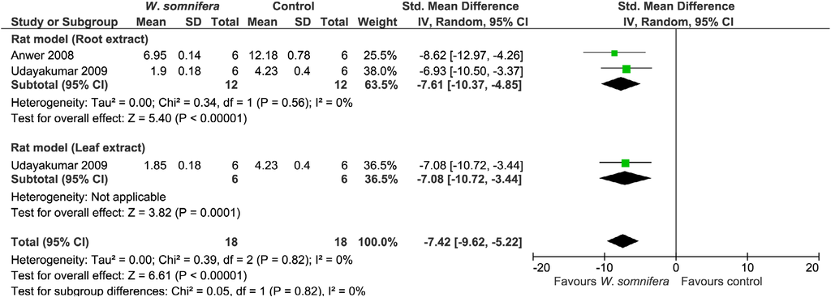

FIGURE 3

Effect of Withania somnifera on glycosylated haemoglobin [Colour figure can be viewed at wileyonlinelibrary.com]

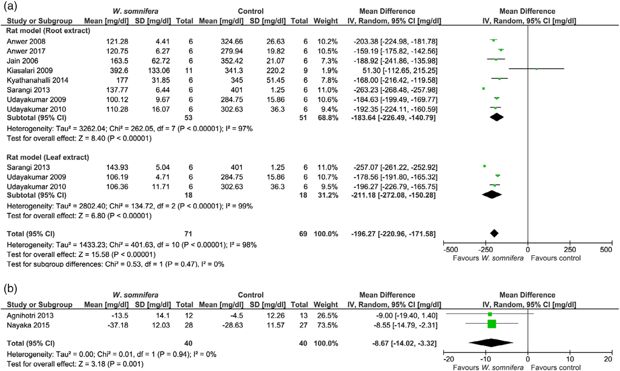

FIGURE 2

Effect of Withania somnifera on (a) blood glucose; (b) on fasting blood glucose [Colour figure can be viewed at wileyonlinelibrary.com]

1054

DURG ET AL.

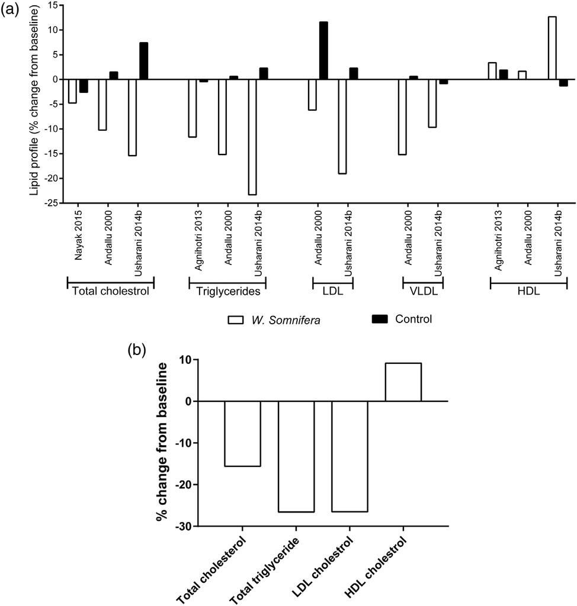

FIGURE 4

Effect of Withania

somnifera on lipid profile: (a) versus

active control/placebo; (b) versus

pre-treatment

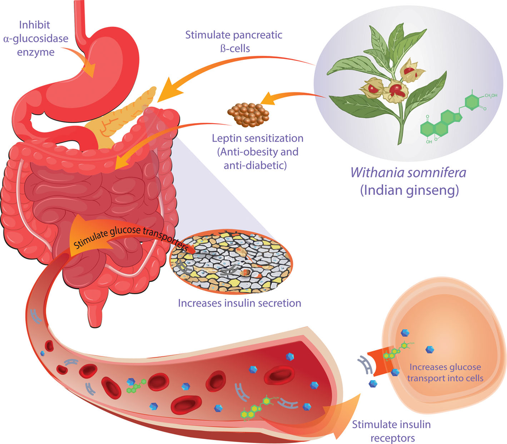

FIGURE 5

Supportive mechanism(s)

of action(s) of Withania somnifera in

diabetes mellitus [Colour figure can be

viewed at wileyonlinelibrary.com]

DURG ET AL.

1055

increased protein catabolism (Almdal & Vilstrup, 1988). W. somnifera

treatment restored AST, ALT, CK and ALP levels to near normal

besides elevated the reduced levels of total protein, albumin and A:G

ratio; these findings support hepato- and reno-protective activities of

W. somnifera in diabetes.

The current meta-analysis was observed with low to significant

heterogeneity in both experimental and clinical studies which can be

attributed to variation in W. somnifera extracts; experimental studies

majorly used aqueous or alcoholic root extract, and leaf extract in

few studies, with different doses. Whereas clinical studies used only

root extract, but not of same concentration (dose) and strength.

Another key factor can be use of different diabetes-inducing agents

and different doses of same agent in pre-clinical studies. In clinical

studies, deviation in diabetes status with or without comorbid condi-

tion, age of included diabetic participants, some patients in addition

to W. somnifera treated with other drugs/supplementation for dia-

betic condition, and duration of the treatment are major key factors

in the noted heterogeneity. Apart from aforementioned factors, the

following also play an important role in pre-clinical studies: experi-

mental animals mimicked either type-1 or type-2 diabetes or both

conditions.

5

|

STRENGTHS

The major strength of this study is systematically incorporating the

mechanistic (in-vitro and pre-clinical) and clinical studies to assess the

anti-diabetic activity of W. somnifera together with its biomarkers.

The literature was searched according to the guideline recommended

databases to identify both published and unpublished (grey) data,

besides hand-searching the references of included articles for addi-

exclusion criteria were applied.

6

|

LIMITATIONS

Clinical data were limited by both quantity and data-type availabil-

ity and accessibility. Of five included clinical studies, four were

tion varied from mild hyperglycemia with hypercholesterolemia or

schizophrenia and type-2 diabetes. Further, only Nayaka et al. eval-

uated the effect of W. somnifera on HbA1c (Nayak et al., 2015), and

the participants in this study in addition to W. somnifera treatment

were

receiving

fixed

dose

regime

of

metformin

(500 mg)

+ glimepride (1 mg); considering this, the effect of W. somnifera on

HbAlc in patients with type-2 diabetes does not hold the impor-

tance. HbA1c, an important test for accessing the long-term glyce-

mic control, which also echo the cumulative glycemic history of the

past 2–3 months (Sherwani, Khan, Ekhzaimy, Masood, & Sakharkar,

2016). A recent case report of W. somnifera root usage (400 mg

BID for 3 months), in an old woman with pre-diabetes (class III obe-

sity, BMI; 49.4 kg/m<sup>2</sup>), reduced HbA1c and body weight, respec-

tively, from 6.4 to 5.9% and 135 to 131.8 kg with no further

changes in lifestyle (Simon, Inoue, Fenteany, Bahtiyar, & Sacerdote,

2018). The clinical studies evaluating the effect of W. somnifera in

patients with type-2 diabetes must measure its effect on HbA1c as

monotherapy, not in combination with allopathic treatment. The

five included clinical studies, in the present systematic evaluation,

were conducted in India, which might limit the generalization of

results to other countries. Of 13 included pre-clinical studies, six

studies did not mention the type of diabetes; however, by virtue of

diabetes inducing agents the experimental animals in these studies

partly mimicked either type-1, type-2 diabetes or both (Durg et al.,

2017). For assessing the efficacy and safety of W. somnifera, appro-

priate standardization and validation is imperative to mimic the

type of diabetes. Another important concern while performing

meta-analysis was plagiarized data. We were able to trace the pla-

giarism in two experimental studies; this cautions the authenticity

of experimental studies, although both studies were excluded from

meta-analysis.

7

|

CONCLUSIONS

ciently robust evidence of the benefits of W. somnifera to recommend

in managing DM. To further strength and validate anti-diabetic profile

of W. somnifera in clinical application, at least one RCT with a larger

sample size and longer duration is warranted with evaluation majorly

for HbA1c, blood glucose and insulin. Future research also needs to

elucidate the molecular mechanism(s) of W. somnifera besides its

active principles in DM.

CONFLICT OF INTEREST

The authors declare no conflicts of interest.

ORCID

Sharanbasappa Durg

https://orcid.org/0000-0003-4319-8451

REFERENCES

Agnihotri,

A.

P.,

Sontakke,

S.

D.,

Thawani,

V.

R.,

Saoji,

A.,

Goswami, V. S. S. (2013). Effects of Withania somnifera in patients of<sup>&</sup>

schizophrenia: A randomized, double blind, placebo controlled pilot

trial study. Indian Journal of Pharmacology, 45(4), 417–418. https://doi.

org/10.4103/0253-7613.115012

Aliper, A., Jellen, L., Cortese, F., Artemov, A., Karpinsky-Semper, D.,

Moskalev, A., … Zhavoronkov, A. (2017). Towards natural mimetics of

metformin and rapamycin. Aging, 9(11), 2245–2268. https://doi.org/

10.18632/aging.101319

Almdal, T. P., & Vilstrup, H. (1988). Strict insulin therapy normalises organ

nitrogen contents and the capacity of urea nitrogen synthesis in exper-

imental diabetes in rats. Diabetologia, 31(2), 114–118. https://doi.org/

10.1007/BF00395558

1056

DURG ET AL.

Andallu,

B.,

&

Radhika,

B.

(2000).

Hypoglycemic,

diuretic

and

hypocholesterolemic effect of winter cherry (Withania somnifera,

Dunal) root. Indian Journal of Experimental Biology, 38(6), 607–609.

Anwer, T., Sharma, M., Khan, G., Alam, M. F., Alam, N., Ali, M. S., &

Alam, M. S. (2017). Preventive role of Withania somnifera on hyperlip-

idemia and cardiac oxidative stress in streptozotocin induced type

2 diabetic rats. Tropical Journal of Pharmaceutical Research, 16(1), 119.

https://doi.org/10.4314/tjpr.v16i1.15

Anwer, T., Sharma, M., Pillai, K. K., & Iqbal, M. (2008). Effect of Withania

somnifera on insulin sensitivity in non-insulin-dependent diabetes

mellitus rats. Basic & Clinical Pharmacology & Toxicology, 102(6),

498–503. https://doi.org/10.1111/j.1742-7843.2008.00223.x

Anwer, T., Sharma, M., Pillai, K. K., & Khan, G. (2012). Protective effect of

Withania somnifera against oxidative stress and pancreatic beta-cell

damage in type 2 diabetic rats. Acta Poloniae Pharmaceutica, 69(6),

1095–1101.

Bhat, J., Damle, A., Vaishnav, P. P., Albers, R., Joshi, M., & Banerjee, G.

(2010). In vivo enhancement of natural killer cell activity through tea

fortified with Ayurvedic herbs. Phytotherapy Research, 24(1), 129–135.

https://doi.org/10.1002/ptr.2889

Chukwuma, C. I., Matsabisa, M. G., Ibrahim, M. A., Erukainure, O. L.,

Chabalala, M. H., & Islam, M. S. (2019). Medicinal plants with concomi-

tant anti-diabetic and anti-hypertensive effects as potential sources of

dual acting therapies against diabetes and hypertension: A review.

Journal of Ethnopharmacology, 235, 329–360. https://doi.org/10.

1016/j.jep.2019.02.024

Dar, N. J., Hamid, A., & Ahmad, M. (2015). Pharmacologic overview of

Withania somnifera, the Indian ginseng. Cellular and Molecular Life Sci-

ences,

72(23),

4445–4460.

https://doi.org/10.1007/s00018-015-

2012-1

de Souza Bastos, A., Graves, D. T., de Melo Loureiro, A. P., Júnior, C. R.,

Corbi, S. C. T., Frizzera, F., … Orrico, S. R. P. (2016). Diabetes and

increased lipid peroxidation are associated with systemic inflammation

even in well-controlled patients. Journal of Diabetes and its Complications,

30(8), 1593–1599. https://doi.org/10.1016/j.jdiacomp.2016.07.011

Department of AYUSH. (1989). The ayurvedic pharmacopoeia, part-I,

volume-I (Vol. 1). Government of India: Ministry of Health and Family

Welfare.

Diabetes Prevention Program Research Group. (2009). 10-year follow-up

of diabetes incidence and weight loss in the diabetes prevention pro-

gram outcomes study. The Lancet, 374(9702), 1677–1686. https://doi.

org/10.1016/S0140-6736(09)61457-4

Diabetes Prevention Program Research Group. (2015). Long-term effects

of lifestyle intervention or metformin on diabetes development and

microvascular complications over 15-year follow-up: The diabetes pre-

vention program outcomes study. The Lancet Diabetes & Endocrinology,

3(11), 866–875. https://doi.org/10.1016/S2213-8587(15)00291-0

Durg, S., Dhadde, S. B., Vandal, R., Shivakumar, B. S., & Charan, C. S.

(2015). Withania somnifera (Ashwagandha) in neurobehavioural disor-

ders induced by brain oxidative stress in rodents: A systematic review

and meta-analysis. Journal of Pharmacy and Pharmacology, 67(7),

879–899. https://doi.org/10.1111/jphp.12398

Durg, S., Shivaram, S. B., & Bavage, S. (2018). Withania somnifera (Indian

ginseng) in male infertility: An evidence-based systematic review and

meta-analysis. Phytomedicine: International Journal of Phytotherapy and

Phytopharmacology, 50, 247–256. https://doi.org/10.1016/j.phymed.

2017.11.011

Durg, S., Veerapur, V. P., Neelima, S., & Dhadde, S. B. (2017). Antidiabetic

activity of Embelia ribes, embelin and its derivatives: A systematic

review and meta-analysis. Biomedicine and Pharmacotherapy, 86,

195–204. https://doi.org/10.1016/j.biopha.2016.12.001

Facciola, S. (1998). Cornucopia II: A source book of edible plants. Facciola,

New York: Kampong Publications.

Fan, D., Li, L., Li, Z., Zhang, Y., Ma, X., Wu, L., & Qin, G. (2018). Effect of

hyperlipidemia on the incidence of cardio-cerebrovascular events in

patients with type 2 diabetes. Lipids in Health and Disease, 17(1), 102.

https://doi.org/10.1186/s12944-018-0676-x

Giacco, F., & Brownlee, M. (2010). Oxidative stress and diabetic complica-

tions. Circulation Research, 107(9), 1058–1070. https://doi.org/10.

1161/CIRCRESAHA.110.223545

Guariguata, L., Whiting, D. R., Hambleton, I., Beagley, J., Linnenkamp, U., &

Shaw, J. E. (2014). Global estimates of diabetes prevalence for 2013

and projections for 2035. Diabetes Research and Clinical Practice, 103

(2), 137–149. https://doi.org/10.1016/j.diabres.2013.11.002

Gupta, S. K., Mohanty, I., Talwar, K. K., Dinda, A., Joshi, S., Bansal, P., …

Arya, D. S. (2004). Cardioprotection from ischemia and reperfusion

injury by Withania somnifera: A hemodynamic biochemical and histo-

pathological assessment. Molecular and Cellular Biochemistry, 260

(1–2),

39–47.

https://doi.org/10.1023/B:MCBI.0000026051.

16803.03

Harris, E. H. (2005). Elevated liver function tests in type 2 diabetes. Clinical

Diabetes, 23(3), 115–119. https://doi.org/10.2337/diaclin.23.3.115

Hasnain, S. Z., Prins, J. B., & McGuckin, M. A. (2016). Oxidative and endo-

plasmic reticulum stress in β-cell dysfunction in diabetes. Journal of

Molecular Endocrinology, 56(2), R33–R54. https://doi.org/10.1530/

JME-15-0232

Huerta, V., Mihalik, K., Becket, K., Maitin, V., & Vattem, D. (2010). Anti-

diabetic and anti-energy harvesting properties of common traditional

herbs, spices and medicinal plants from India. Journal of Natural Reme-

dies, 10(2), 123–135. https://doi.org/10.18311/jnr/2010/253

Ingram, D. K., Anson, R. M., De Cabo, R., Mamczarz, J., Zhu, M.,

Mattison, J., … Roth, G. S. (2004). Development of calorie restriction

mimetics as a prolongevity strategy. Annals of the New York Academy

of Sciences, 1019, 412–423. https://doi.org/10.1196/annals.1297.074

Jain, S., Pandhi, P., Singh, A., & Malhotra, S. (2006). Efficacy of

standardised herbal extracts in type 1 diabetes-an experimental study.

African Journal of Traditional, Complementary and Alternative Medicines,

3(4), 23–33.

Jonathan, G., Rivka, R., Avinoam, S., Lumír, H., & Nirit, B. (2015). Hypogly-

cemic activity of withanolides and elicitated Withania somnifera. Phyto-

chemistry,

116(1),

283–289.

https://doi.org/10.1016/j.phytochem.

2015.02.029

Kaul, S. C., & Wadhwa, R. (Eds.). (2017). Science of Ashwagandha: Preventive

and therapeutic potentials. Cham: Springer International Publishing.

https://doi.org/10.1007/978-3-319-59192-6

Khan, M. A., Khan, H., & Ali, T. (2014). Withanolides isolated from Withania

somnifera with α-glucosidase inhibition. Medicinal Chemistry Research, 23

(5), 2386–2390. https://doi.org/10.1007/s00044-013-0838-3

Kiasalari, Z., Khalili, M., & Aghaei, M. (2009). Effect of Withania

somniferaon levels of sex hormonesin the diabetic male rats. Iranian

Journal of Reproductive Medicine, 7(4), 163–168.

Knowler, W. C., Barrett-Connor, E., Fowler, S. E., Hamman, R. F.,

Lachin, J. M., Walker, E. A., … Diabetes Prevention Program

Research Group. (2002). Reduction in the incidence of type

2 diabetes with lifestyle intervention or metformin. New England

Journal of Medicine, 346(6), 393–403. https://doi.org/10.1056/

NEJMoa012512

Krauss, R. M. (2004). Lipids and lipoproteins in patients with type 2 diabe-

tes. Diabetes Care, 27(6), 1496–1504.

Kulkarni, S. K., & Dhir, A. (2008). Withania somnifera: An Indian gin-

seng. Progress in Neuro-Psychopharmacology and Biological Psychia-

try,

32(5),

1093–1105.

https://doi.org/10.1016/j.pnpbp.2007.

09.011

Kuppurajan, K., Rajagopalan, S., Sitaraman, R., Rajagopalan, V., Janaki, K.,

Revathi, R., & Venkataraghavan, S. (1980). Effects of Ashwagandha on

the process of ageing on human volunteers. Journal of Research in

Ayurveda & Siddha, 1, 247–258.

Kyathanahalli, C. N., Manjunath, M. J., & Muralidhara. (2014). Oral supple-

mentation of standardized extract of Withania somnifera protects

against

diabetes-induced

testicular

oxidative

impairments

in

DURG ET AL.

1057

prepubertal rats. Protoplasma, 251(5), 1021–1029. https://doi.org/10.

1007/s00709-014-0612-5

Lee, J., Liu, J., Feng, X., Hernández, M. A. S., Mucka, P., Ibi, D., … Ozcan, U.

(2016). Withaferin a is a leptin sensitizer with strong antidiabetic prop-

erties in mice. Nature Medicine, 22(9), 1023–1032. https://doi.org/10.

1038/nm.4145

Lenzen, S. (2008). The mechanisms of alloxan- and streptozotocin-induced

diabetes.

Diabetologia,

51(2),

216–226.

https://doi.org/10.1007/

s00125-007-0886-7

Liberati, A., Altman, D. G., Tetzlaff, J., Mulrow, C., Gøtzsche, P. C.,

Ioannidis, J. P. A., … Moher, D. (2009). The PRISMA statement for

reporting systematic reviews and meta-analyses of studies that

evaluate health care interventions: Explanation and elaboration.

PLoS Medicine, 6(7), e1000100. https://doi.org/10.1371/journal.

Lim,<sup>pmed.1000100</sup>

E.

L.,

Hollingsworth,

K.

G.,

Aribisala,

B.

S.,

Chen,

M.

J.,

Mathers, J. C., & Taylor, R. (2011). Reversal of type 2 diabetes:

Normalisation of beta cell function in association with decreased pan-

creas

and liver

triacylglycerol.

Diabetologia, 54(10),

2506–2514.

https://doi.org/10.1007/s00125-011-2204-7

Lopresti, A. L., Drummond, P. D., & Smith, S. J. (2019). A randomized,

double-blind, placebo-controlled, crossover study examining the hor-

monal and vitality effects of Ashwagandha (Withania somnifera) in

aging, overweight males. American Journal of Men's Health, 13(2),

1–15. https://doi.org/10.1177/1557988319835985

Mills, S. Y., Simon Mills, M. F. M. A., & Bone, K. (2004). The essential guide

to herbal safety. St. Louis, Missouri: Elsevier Health Sciences.

Mirjalili, M. H., Moyano, E., Bonfill, M., Cusido, R. M., & Palazón, J. (2009).

Steroidal lactones from Withania somnifera, an ancient plant for novel

medicine.

Molecules,

14(7),

2373–2393.

https://doi.org/10.3390/

molecules14072373

Mishra, S. K., Venkatachalapathy, B. A., & Khanli, H. M. (2017). Safety and

efficacy of Ashwagandha (Withania somnifera). In Neuroprotective natu-

ral products: Clinical aspects and mode of action (pp. 313–319).

Weinheim, Germany: Wiley-VCH Verlag GmbH & Co. KGaA. https://

doi.org/10.1002/9783527803781.ch12

Narayana, D., & Durg, S. (2019). Approaches to safety evaluation of botan-

icals and processed botanicals known in traditional knowledge. In

D. Ghosh & P. Mukherjee (Eds.), Natural medicines: Clinical efficacy,

safety and quality (pp. 187–214). Boca Raton, FL: CRC Press. https://

doi.org/10.1201/9781315187853-10

Narayana,

D.

B.

A.,

Durg,

S.,

Manohar,

P.

R.,

Mahapatra,

A.,

Aramya, A. R. (2017). Chyawanprash: A review of therapeutic benefits<sup>&</sup>

as in authoritative texts and documented clinical literature. Journal of

Ethnopharmacology, 197, 52–60. https://doi.org/10.1016/j.jep.2016.

07.078

Nayak, S., Nayak, S., Panda, B., & Das, S. (2015). A clinical study on

management of stress in type-2 diabetes mellitus (Madhumeha)

with

ashwagandha

(Withania

somnifera).

Ayushdhara,

2(6),

413–417.

Nirupama, R., Devaki, M., Nirupama, M., & Yajurvedi, H. (2014). In

vitro and in vivo studies on the hypoglycaemic potential of

Ashwagandha (Withania somnifera) root. Pharma Science Monitor, 5

(3), 45–58.

Parihar, M. S., Chaudhary, M., Shetty, R., & Hemnani, T. (2004). Suscepti-

bility of hippocampus and cerebral cortex to oxidative damage in

streptozotocin treated mice: Prevention by extracts of Withania som-

nifera and Aloe vera. Journal of Clinical Neuroscience, 11(4), 397–402.

https://doi.org/10.1016/j.jocn.2003.09.008

Parihar, P., Shetty, R., Ghafourifar, P., & Parihar, M. S. (2016). Increase in

oxidative stress and mitochondrial impairment in hypothalamus of

streptozotocin treated diabetic rat: Antioxidative effect of Withania

somnifera. Cellular and Molecular Biology, 62(1), 73–83. https://doi.org/

10.14715/cmb/2016.62.1.15

Patel, S. B., Rao, N. J., & Hingorani, L. L. (2016). Safety assessment of

Withania somnifera extract standardized for Withaferin A: Acute and

sub-acute toxicity study. Journal of Ayurveda and Integrative Medicine,

7(1), 30–37. https://doi.org/10.1016/j.jaim.2015.08.001

Raut, A., Rege, N., Shirolkar, S., Pandey, S., Tadvi, F., Solanki, P., … Kene, K.

(2012). Exploratory study to evaluate tolerability, safety, and activity

of Ashwagandha (Withania somnifera) in healthy volunteers. Journal of

Ayurveda and Integrative Medicine, 3(3), 111–114. https://doi.org/10.

4103/0975-9476.100168

Reuland, D. J., Khademi, S., Castle, C. J., Irwin, D. C., McCord, J. M.,

Miller, B. F., & Hamilton, K. L. (2013). Upregulation of phase II enzymes

through phytochemical activation of Nrf2 protects cardiomyocytes

against oxidant stress. Free Radical Biology and Medicine, 56, 102–111.

https://doi.org/10.1016/j.freeradbiomed.2012.11.016

Salmela, P. I., Sotaniemi, E. A., Niemi, M., & Mäentausta, O. (1984). Liver

function tests in diabetic patients. Diabetes Care, 7(3), 248–254.

https://doi.org/10.2337/diacare.7.3.248

Samadi Noshahr, Z., Shahraki, M. R., Ahmadvand, H., Nourabadi, D., &

Nakhaei, A. (2015). Protective effects of Withania somnifera root on

inflammatory markers and insulin resistance in fructose-fed rats.

Reports of Biochemistry & Molecular Biology, 3(2), 62–67.

Sandhu, J. S., Shah, B., Shenoy, S., Chauhan, S., Lavekar, G. S., &

Padhi, M. M. (2010). Effects of Withania somnifera (Ashwagandha) and

Terminalia arjuna (Arjuna) on physical performance and cardiorespira-

tory endurance in healthy young adults. International Journal of Ayur-

veda Research, 1(3), 144–149. https://doi.org/10.4103/0974-7788.

72485

Sarangi, A., Jena, S., Sarangi, A. K., & Swain, B. (2013). Anti-diabetic effects

of Withania somnifera root and leaf extracts on streptozotocin induced

diabetic rats. Journal of Cell and Tissue Research, 13(1), 3597–3601.

Sarjan, H., & Yajurvedi, H. (2018). Efficacy of an active compound of the

herb, Ashwagandha in prevention of stress induced hyperglycemia.

International Journal of Pharmacy and Pharmaceutical Sciences, 10(10),

44. https://doi.org/10.22159/ijpps.2018v10i10.28717

Shah, R. A., Khan, S., Vakil, M., & Qureshi, M. T. (2017). Evaluation of anti-

diabetic potential of Withania somnifera by glucose uptake assay

on3T3 F442A fibroblast (adipocyte) cells. International Journal of Phar-

maceutical Sciences and Research, 8(1), 120–125. https://doi.org/10.

13040/IJPSR.0975-8232.8(1).120-25

Shahraki, M. R., Samadi Noshahr, Z., Ahmadvand, H., & Nakhaie, A. (2016).

Anti-nociceptive and anti-inflammatory effects of Withania somnifera

root in fructose fed male rats. Journal of Basic and Clinical Physiology

and Pharmacology, 27(4), 387–391. https://doi.org/10.1515/jbcpp-

2015-0053

Sharma, H., & Chandola, H. M. (2011). Prameha in ayurveda: Correlation

with obesity, metabolic syndrome, and diabetes mellitus. Part 1–etiol-

ogy, classification, and pathogenesis. The Journal of Alternative and

Complementary Medicine, 17(6), 491–496. https://doi.org/10.1089/

acm.2010.0396

Sherwani, S. I., Khan, H. A., Ekhzaimy, A., Masood, A., & Sakharkar, M. K.

(2016). Significance of HbA1c test in diagnosis and prognosis of dia-

betic patients. Biomarker Insights, 11, 95–104. https://doi.org/10.

4137/BMI.S38440

Simon, K., Inoue, T., Fenteany, G., Bahtiyar, G., & Sacerdote, A. (2018).

Ashwagandha root in the treatment of prediabetes. Endocrine Reviews,

39(2) Supplement 1, Page i. https://doi.org/10.1093/edrv/39.supp_

2.1

Singh, A. K., Joshi, J., & Jatwa, R. (2013). Dipeptidyl peptidase IV

(CD26/DPP-IV) inhibitory and free radical scavenging potential of W

somnifera and T foenum-graecum extract. International Journal of

Phytomedicine,

5(4),

503–509.

https://doi.org/10.5138/ijpm.v5i4.

1212

Szkudelski, T. (2001). The mechanism of alloxan and streptozotocin action

in B cells of the rat pancreas. Physiological Research, 50(6), 537–546.

1058

DURG ET AL.

Tangvarasittichai, S. (2015). Oxidative stress, insulin resistance, dys-

lipidemia and type 2 diabetes mellitus. World Journal of Diabetes, 6(3),

456–480. https://doi.org/10.4239/wjd.v6.i3.456

Tekula, S., Khurana, A., Anchi, P., & Godugu, C. (2018). Withaferin-A atten-

uates multiple low doses of streptozotocin (MLD-STZ) induced type

1 diabetes. Biomedicine & Pharmacotherapy, 106, 1428–1440. https://

doi.org/10.1016/j.biopha.2018.07.090

Thakur, A., Dey, A., Shyam Chatterjee, S., & Kumar, V. (2015). Reverse

ayurvedic pharmacology of Ashwagandha as an adaptogenic anti-

diabetic plant: A pilot study. Current Traditional Medicine, 1(1), 51–61.

https://doi.org/10.2174/2215083801999150527115205

Tuomilehto, J., Lindström, J., Eriksson, J. G., Valle, T. T., Hämäläinen, H.,

Ilanne-Parikka, P., … Uusitupa, M. (2001). Prevention of type 2 diabetes

mellitus by changes in lifestyle among subjects with impaired glucose

tolerance. New England Journal of Medicine, 344(18), 1343–1350.

https://doi.org/10.1056/NEJM200105033441801

Udayakumar,

R.,

Kasthurirengan,

S.,

Mariashibu,

T.

S.,

Rajesh,

M.,

Anbazhagan, V. R., Kim, S. C., … Choi, C. W. (2009). Hypoglycaemic

and hypolipidaemic effects of Withania somnifera root and leaf extracts

on alloxan-induced diabetic rats. International Journal of Molecular Sci-

ences, 10(5), 2367–2382. https://doi.org/10.3390/ijms10052367

Udayakumar, R., Kasthurirengan, S., Vasudevan, A., Mariashibu, T. S.,

Rayan, J. J. S., Choi, C. W., … Kim, S. C. (2010). Antioxidant effect of

dietary supplement Withania somnifera L. reduce blood glucose levels

in Alloxan-induced diabetic rats. Plant Foods for Human Nutrition, 65

(2), 91–98. https://doi.org/10.1007/s11130-009-0146-8

Usharani, P., Fatima, N., Kumar, C., & Kishan, P. (2014). Evaluation of a

highly standardized Withania somnifera extract on endothelial dysfunc-

tion and biomarkers of oxidative stress in patients with type 2 diabetes

mellitus: A randomized, double blind, placebo controlled study. Interna-

tional Journal of Ayurveda and Pharma Research, 2(3), 22–32.

Usharani, P., Kishan, P., Fatima, N., & Kumar, C. (2014). A comparative

study to evaluate the effect of highly standardised aqueous extracts of

Phyllanthus emblica, Withania somnifera and their combination on

endothelial dysfunction and biomarkers in patients with type II diabe-

tes mellitus. International Journal of Pharmaceutical Sciences and

Research,

5(7),

2687–2697.

https://doi.org/10.13040/IJPSR.0975-

8232.5(6).2687-97

Visavadiya,

N.

P.,

&

Narasimhacharya,

A.

V.

R.

L.

(2007).

Hyp-

ocholesteremic and antioxidant effects of Withania somnifera (Dunal)

in hypercholesteremic rats. Phytomedicine, 14(2–3), 136–142. https://

doi.org/10.1016/j.phymed.2006.03.005

Wagner, A. M., Martijnez-Rubio, A., Ordonez-Llanos, J., & Perez-Perez, A.

(2002). Diabetes mellitus and cardiovascular disease. European Journal

of Internal Medicine, 13(1), 15–30.

Weiner, M., & Weiner, J. (1994). Ashwagandha (Indian ginseng). In

M. Weiner & J. Weiner (Eds.), Herbs that heal. Mill Valley, California:

Quantum Books, (pp. 70–72).

World Health Organization. (2016). Global report on diabetes. ISBN:

978 92 4 156525 7.

SUPPORTING INFORMATION

Additional supporting information may be found online in the

Supporting Information section at the end of this article.

How to cite this article: Durg S, Bavage S, Shivaram SB.

Withania somnifera (Indian ginseng) in diabetes mellitus: A

systematic review and meta-analysis of scientific evidence

from experimental research to clinical application.

Phytotherapy Research. 2020;34:1041–1059. https://doi.org/

10.1002/ptr.6589

DURG ET AL.

1059